# Peramalan Harga Adjusted Closing IHSG Periode Januari 2017 - 31 Maret 2022

# Uji diagnostik data yang telah ditransformasi

```r
ihsg.tfed.residual1 <- ihsg.tfed.model1$residuals
ihsg.tfed.residual2 <- ihsg.tfed.model2$residuals
ihsg.tfed.residual3 <- ihsg.tfed.model3$residuals
ihsg.tfed.residual4 <- ihsg.tfed.model4$residuals
```

## Normalitas

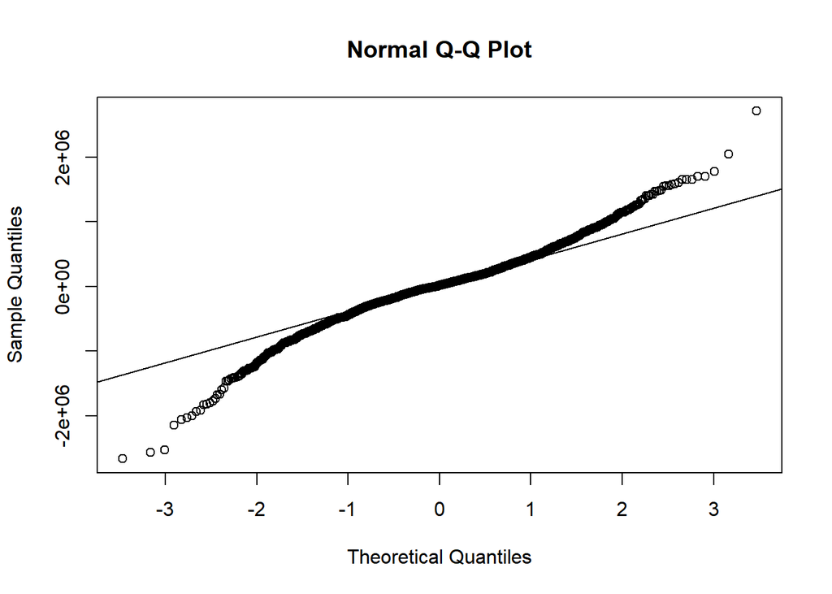

```r
qqnorm(ihsg.tfed.residual1)
qqline(ihsg.tfed.residual1)
```

```r
jarque.bera.test(ihsg.tfed.residual1)
```

```
##
##  Jarque Bera Test
##
## data:  ihsg.tfed.residual1
## X-squared = 503.02, df = 2, p-value < 2.2e-16
```

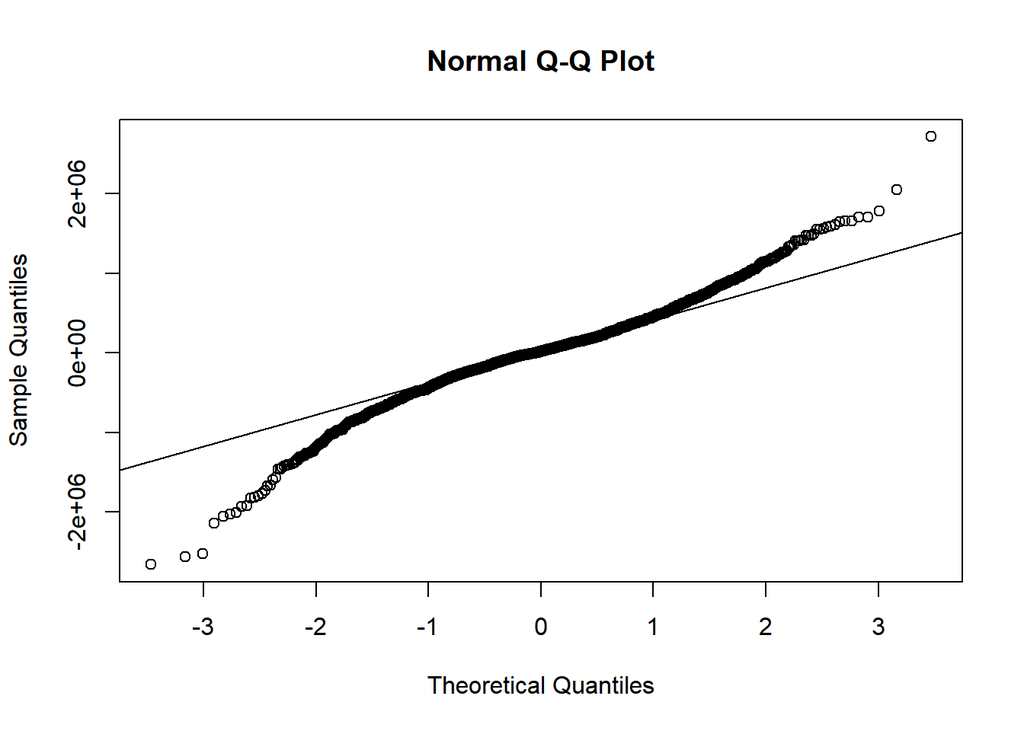

```r
qqnorm(ihsg.tfed.residual2)
qqline(ihsg.tfed.residual2)
```

```r
jarque.bera.test(ihsg.tfed.residual2)
```

```
##
##  Jarque Bera Test
##
## data:  ihsg.tfed.residual2
## X-squared = 502.83, df = 2, p-value < 2.2e-16
```

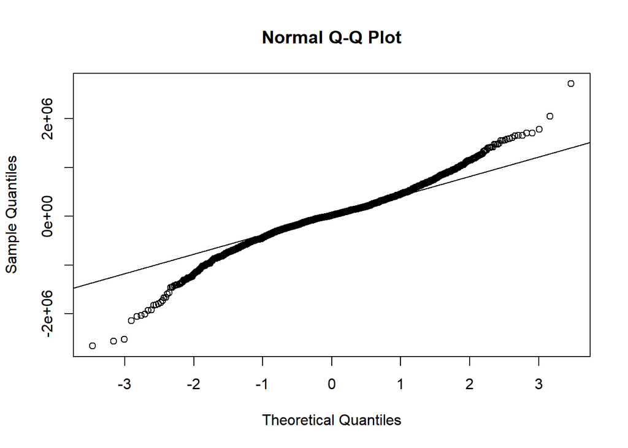

```r
qqnorm(ihsg.tfed.residual3)
qqline(ihsg.tfed.residual3)
```

```r
jarque.bera.test(ihsg.tfed.residual3)
```

```
##
##  Jarque Bera Test
##
## data:  ihsg.tfed.residual3
## X-squared = 502.71, df = 2, p-value < 2.2e-16
```

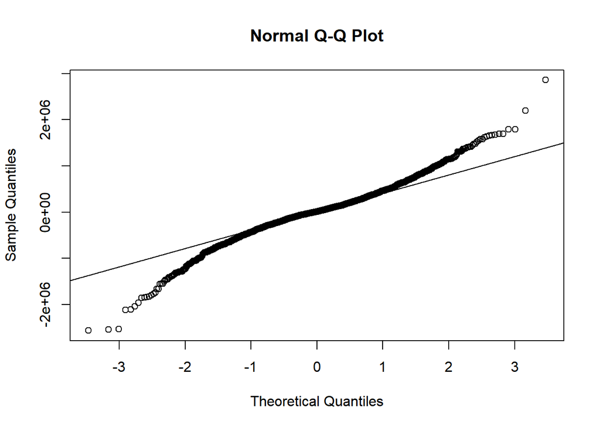

```r
qqnorm(ihsg.tfed.residual4)
qqline(ihsg.tfed.residual4)
```

```r
jarque.bera.test(ihsg.tfed.residual4)
```

```
##
##  Jarque Bera Test
##
## data:  ihsg.tfed.residual4
## X-squared = 503.17, df = 2, p-value < 2.2e-16
```

Berdasarkan qq-plot dan uji formal Jarque Bera, sisaan data yang telah ditransformasi cenderung tidak menyebar normal sehingga asumsi normalitas tetap tidak terpenuhi.

## Kehomogenan Ragam

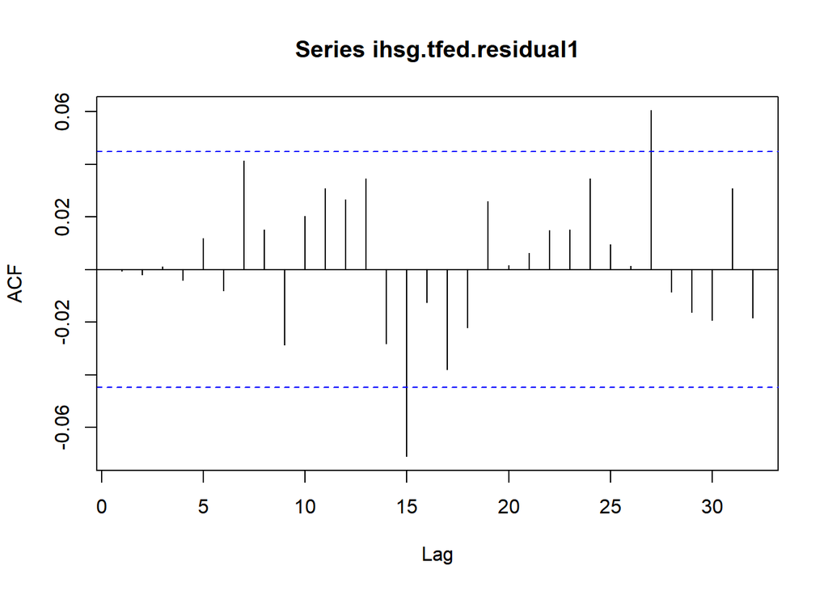

```r
acf(ihsg.tfed.residual1)
```

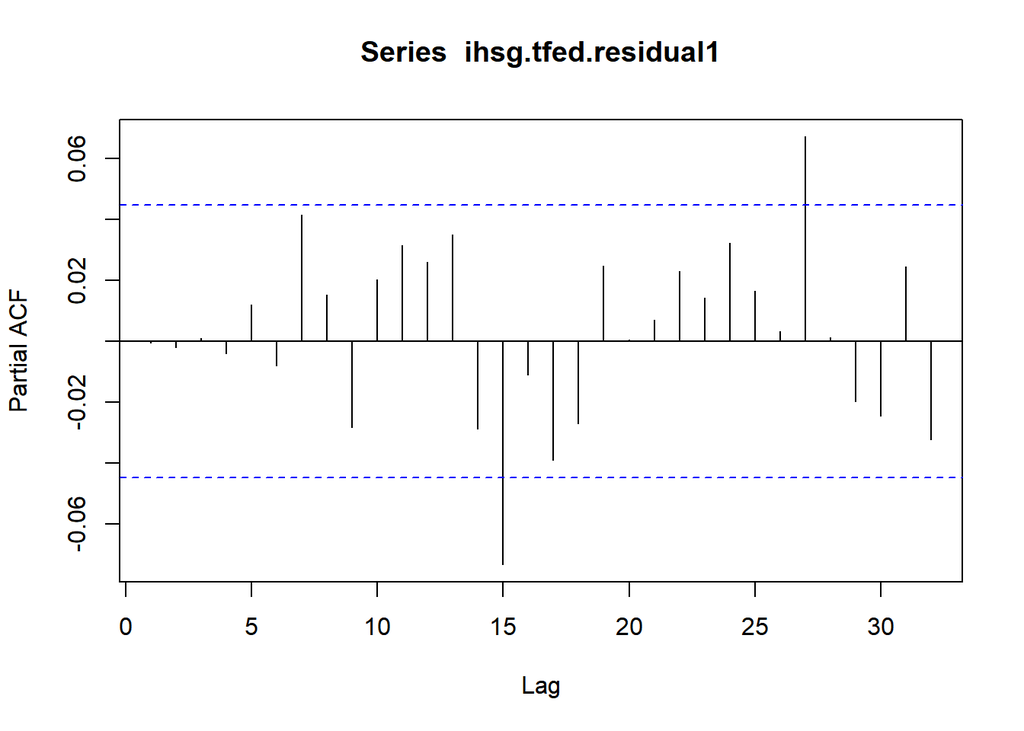

```r
pacf(ihsg.tfed.residual1)
```

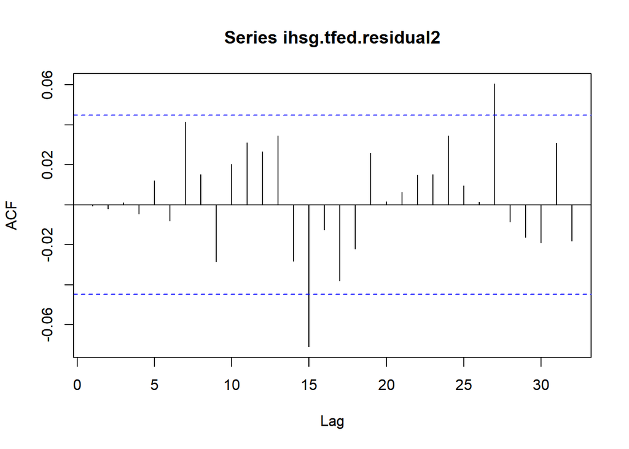

```r
acf(ihsg.tfed.residual2)
```

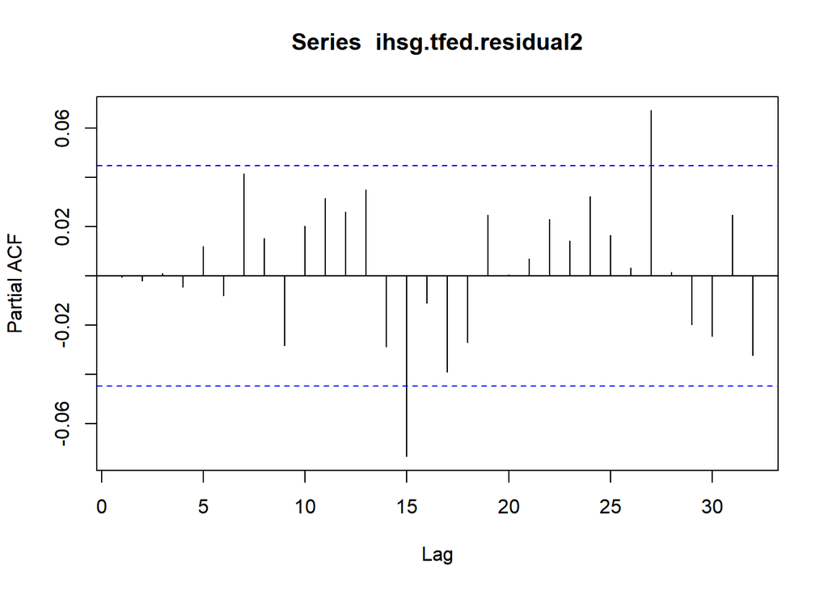

```r
pacf(ihsg.tfed.residual2)
```

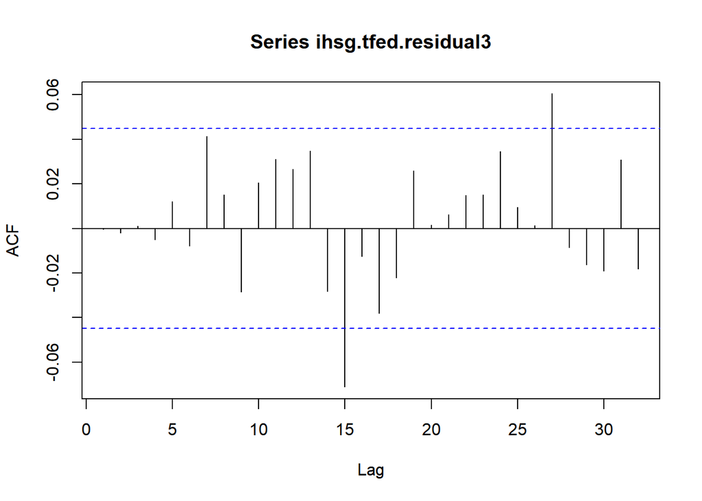

```r
acf(ihsg.tfed.residual3)
```

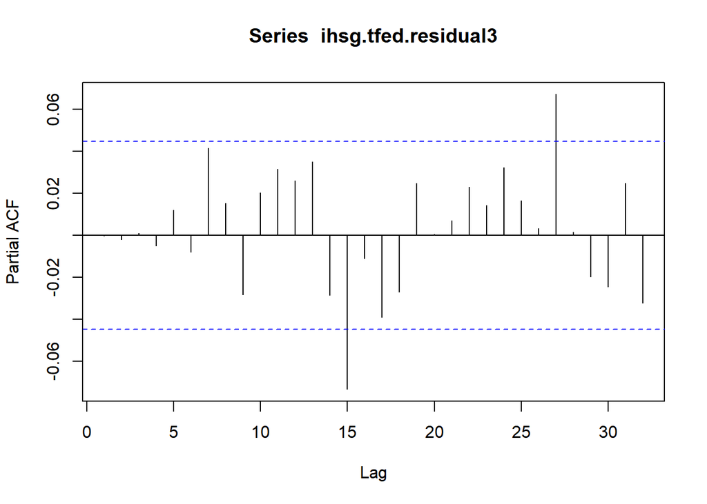

```r
pacf(ihsg.tfed.residual3)
```

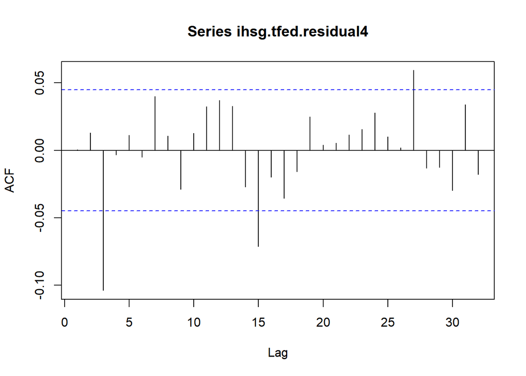

```r
acf(ihsg.tfed.residual4)
```

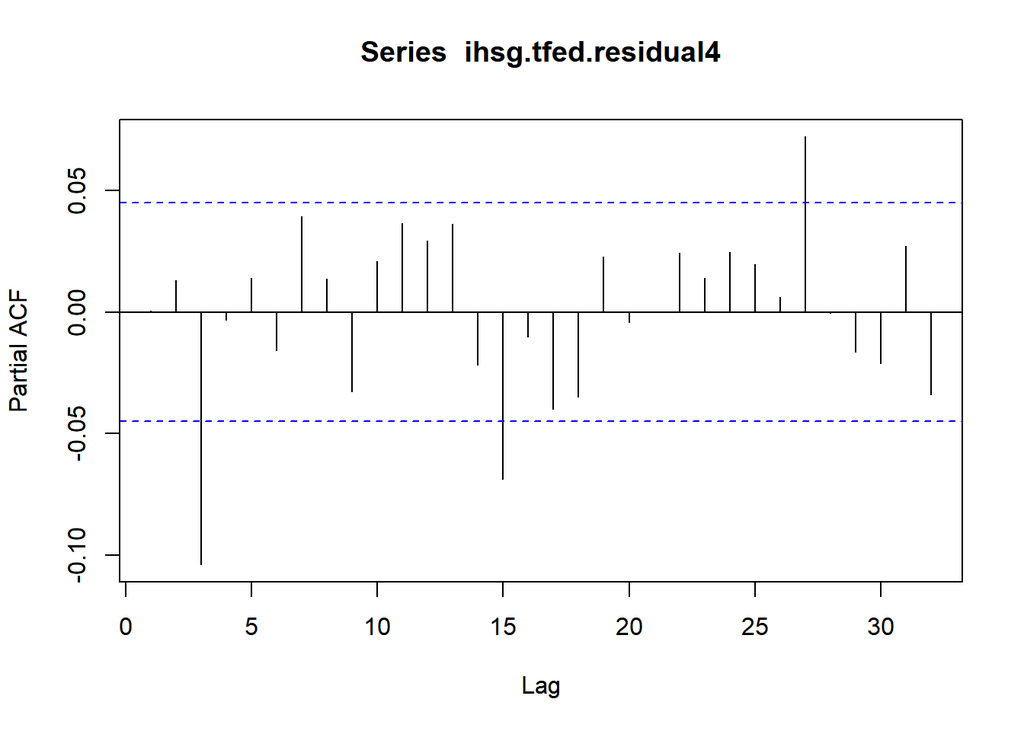

```r
pacf(ihsg.tfed.residual4)
```

## Autokorelasi

```r
Box.test(ihsg.tfed.residual1, type="Ljung")
```

```
##
##  Box-Ljung test
##
## data:  ihsg.tfed.residual1
## X-squared = 0.00049184, df = 1, p-value = 0.9823
```

```r
Box.test(ihsg.tfed.residual2, type="Ljung")
```

```
##
##  Box-Ljung test
##
## data:  ihsg.tfed.residual2
## X-squared = 0.0003742, df = 1, p-value = 0.9846
```

```r
Box.test(ihsg.tfed.residual3, type="Ljung")
```

```
##
##  Box-Ljung test
##
## data:  ihsg.tfed.residual3
## X-squared = 0.0002962, df = 1, p-value = 0.9863
```

```r
Box.test(ihsg.tfed.residual4, type="Ljung")
```

```
##
##  Box-Ljung test
##
## data:  ihsg.tfed.residual4
## X-squared = 0.00052517, df = 1, p-value = 0.9817
```

Berdasarkan hasil Ljung-Box test, terlihat bahwa data telah memenuhi asumsi tidak adanya autokorelasi.

Karena hasil uji diagnostik pada data yang telah ditransformasi juga tidak lolos asumsi normalitas sisaan maka tidak bisa dilakukan peramalan.

# Sesonal ARIMA (SARIMA)

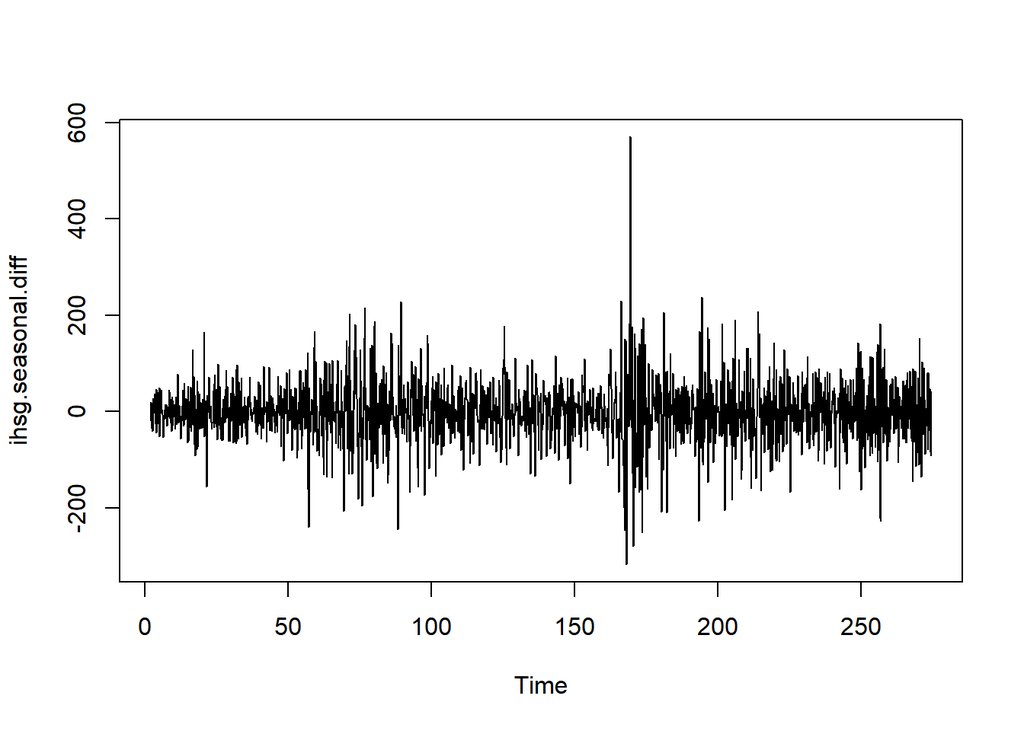

```r
ihsg.seasonal <- ts(ihsg.imputed$JKSE.Adjusted, frequency=7)
ihsg.seasonal.diff <- diff(diff(ihsg.seasonal,1),7)
ts.plot(ihsg.seasonal.diff)
```

Karena pada bagian sebelumnya kita telah menyadari bahwa perlu dilakukan differencing non-seasonal sebanyak 1 kali agar data stasioner, maka akan kembali dilakukan differencing.

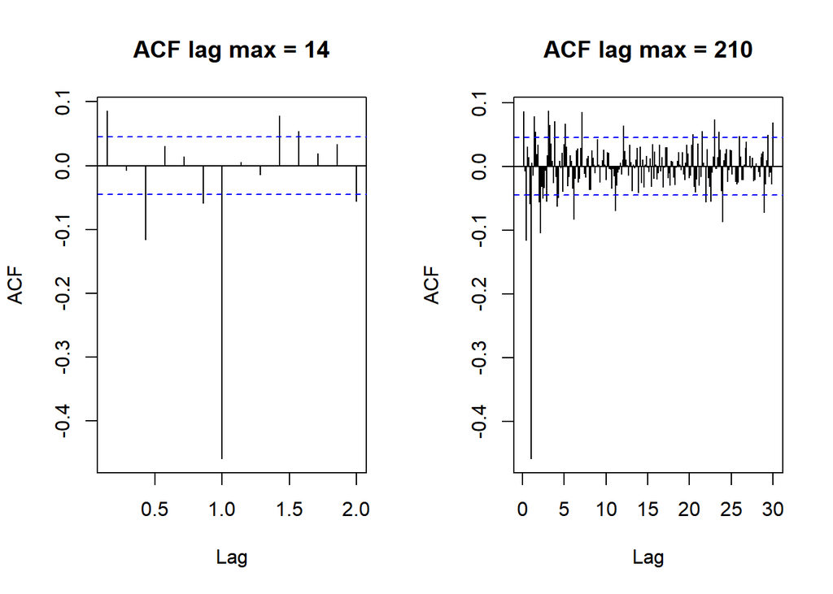

```r
par(mfrow=c(1,2))
acf(ihsg.seasonal.diff, lag.max = 14, main="ACF lag max = 14")
acf(ihsg.seasonal.diff, lag.max = 210, main="ACF lag max = 210")
```

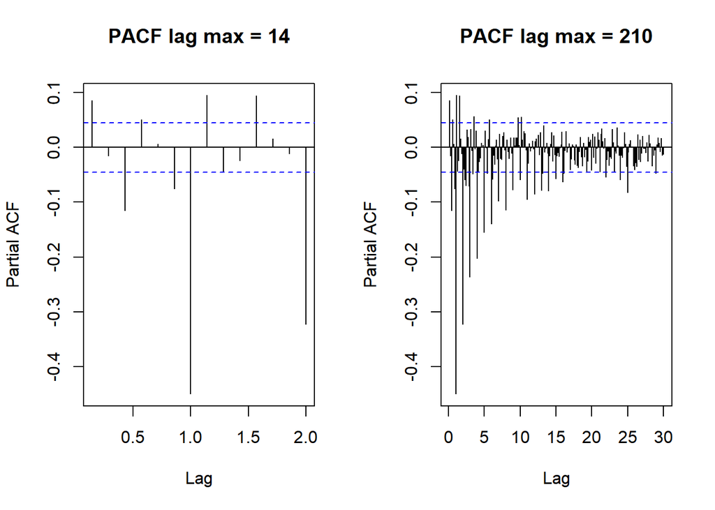

```r
pacf(ihsg.seasonal.diff, lag.max = 14, main="PACF lag max = 14")
pacf(ihsg.seasonal.diff, lag.max = 210, main="PACF lag max = 210")
```

```r
par(mfrow = c(1,1))
```

Plot PACF menunjukkan cutoff di lag ke-1 atau ke-4 dan nilai PACF menurun pada lag musiman (namun secara perlahan) atau tail off, maka memperkuat dugaan bahwa model yang cocok merupakan MA(1) musiman.

```r
eacf(ihsg.seasonal.diff)
```

```
## AR/MA
##   0 1 2 3 4 5 6 7 8 9 10 11 12 13
## 0 x o x o o x x o o x x  o  o  x
## 1 x o x x o o x x o x o  o  o  o
## 2 x x x o o o x x o x o  o  o  o
## 3 x x x o o o x x x x o  o  o  o
## 4 x x o x o o x x x o x  o  o  o
## 5 x x o x x o x x x o x  x  o  o
## 6 x o x x x x x x x x x  o  o  o
## 7 x x x x x o x x x x x  o  x  x
```

## Pemodelan

```r
ihsg.seasonal.model1 <- Arima(ihsg.seasonal, order=c(0,1,3), seasonal=c(0,1,1), method="ML")
ihsg.seasonal.model2 <- Arima(ihsg.seasonal, order=c(0,1,4), seasonal=c(0,1,1), method="ML")
ihsg.seasonal.model3 <- Arima(ihsg.seasonal, order=c(1,1,4), seasonal=c(0,1,1), method="ML")
ihsg.seasonal.model4 <- Arima(ihsg.seasonal, order=c(0,1,1), seasonal=c(0,1,1), method="ML")
ihsg.seasonal.model1$aic; ihsg.seasonal.model2$aic; ihsg.seasonal.model3$aic; ihsg.seasonal.model4$aic
```

```
## [1] 20059.86
```

```
## [1] 20061.84
```

```
## [1] 20063.81
```

```
## [1] 20079.87
```

Berdasarkan model SARIMA yang dibuat, terlihat bahwa nilai AIC paling kecil adalah model ARIMA(0,1,3)(0,1,1)7

Akan diperiksa koefisien dari tiap model

```r
coeftest(ihsg.seasonal.model1)
```

```
##
## z test of coefficients:
##
##       Estimate Std. Error  z value  Pr(>|z|)
## ma1   0.090200   0.022654   3.9816 6.845e-05 ***
## ma2   0.007755   0.022647   0.3424     0.732
## ma3  -0.113503   0.023131  -4.9070 9.247e-07 ***
## sma1 -0.999989   0.013888 -72.0018 < 2.2e-16 ***
## ---
## Signif. codes:  0 '***' 0.001 '**' 0.01 '*' 0.05 '.' 0.1 ' ' 1
```

```r
coeftest(ihsg.seasonal.model2)
```

```
##
## z test of coefficients:
##
##        Estimate Std. Error  z value  Pr(>|z|)
## ma1   0.0896063  0.0230247   3.8918 9.952e-05 ***
## ma2   0.0078541  0.0227428   0.3453    0.7298
## ma3  -0.1134941  0.0231329  -4.9062 9.287e-07 ***
## ma4   0.0034186  0.0223473   0.1530    0.8784
## sma1 -0.9999923  0.0136240 -73.3993 < 2.2e-16 ***
## ---
## Signif. codes:  0 '***' 0.001 '**' 0.01 '*' 0.05 '.' 0.1 ' ' 1
```

```r
coeftest(ihsg.seasonal.model3)
```

```
##
## z test of coefficients:
##
##        Estimate Std. Error  z value  Pr(>|z|)
## ar1   0.0441896        NaN      NaN       NaN
## ma1   0.0452642        NaN      NaN       NaN
## ma2   0.0039220        NaN      NaN       NaN
## ma3  -0.1138286  0.0223386  -5.0956 3.476e-07 ***
## ma4   0.0097853        NaN      NaN       NaN
## sma1 -0.9999812  0.0135324 -73.8953 < 2.2e-16 ***
## ---
## Signif. codes:  0 '***' 0.001 '**' 0.01 '*' 0.05 '.' 0.1 ' ' 1
```

```r
coeftest(ihsg.seasonal.model4)
```

```
##
## z test of coefficients:
##
##        Estimate Std. Error  z value  Pr(>|z|)
## ma1   0.0876104  0.0223780    3.915 9.039e-05 ***
## sma1 -0.9999996  0.0099033 -100.977 < 2.2e-16 ***
## ---
## Signif. codes:  0 '***' 0.001 '**' 0.01 '*' 0.05 '.' 0.1 ' ' 1
```

Kita dapat lihat bahwa seluruh koefisien ARIMA(0,1,1)(0,1,1)7 signifikan sedangkan yang lain hanya sebagian yang signifikan.

## Uji Diagnostik

```r
ihsg.seasonal.residual1 <- ihsg.seasonal.model1$residuals
ihsg.seasonal.residual2 <- ihsg.seasonal.model2$residuals
ihsg.seasonal.residual3 <- ihsg.seasonal.model3$residuals
ihsg.seasonal.residual4 <- ihsg.seasonal.model4$residuals
```

## Normalitas

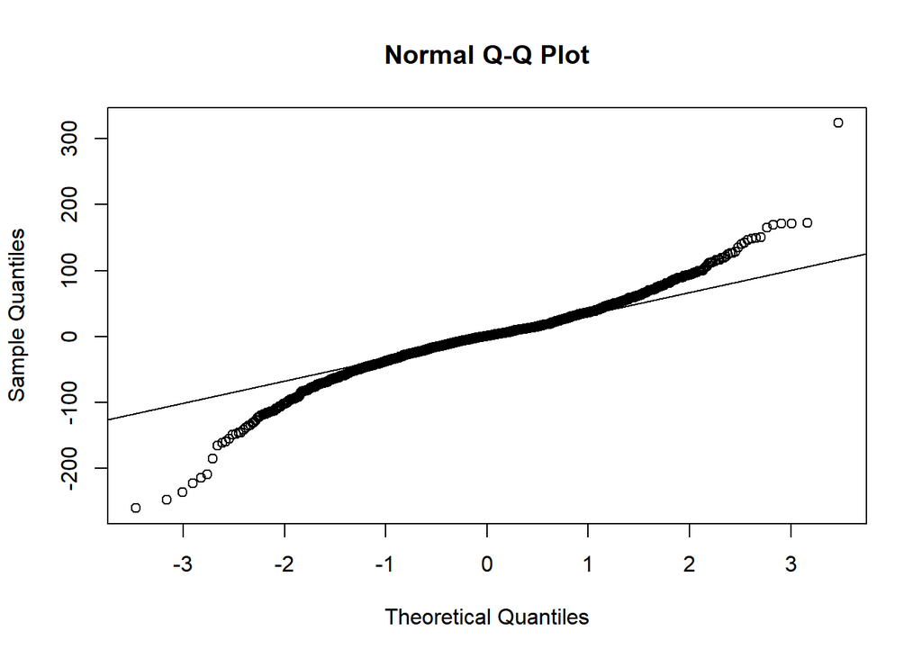

```r
qqnorm(ihsg.seasonal.residual1)
qqline(ihsg.seasonal.residual1)
```

```r
jarque.bera.test(ihsg.seasonal.residual1)
```

```
##
##  Jarque Bera Test
##
## data:  ihsg.seasonal.residual1
## X-squared = 1480.6, df = 2, p-value < 2.2e-16
```

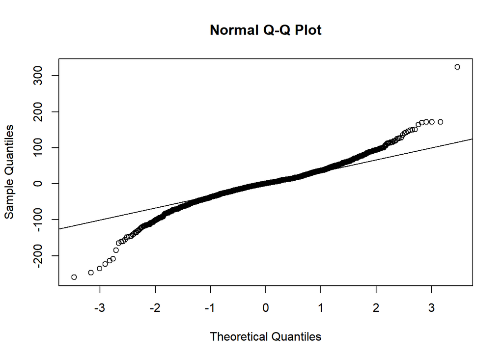

```r
qqnorm(ihsg.seasonal.residual2)
qqline(ihsg.seasonal.residual2)
```

```r
jarque.bera.test(ihsg.seasonal.residual2)
```

```
##
##  Jarque Bera Test
##
## data:  ihsg.seasonal.residual2
## X-squared = 1479.7, df = 2, p-value < 2.2e-16
```

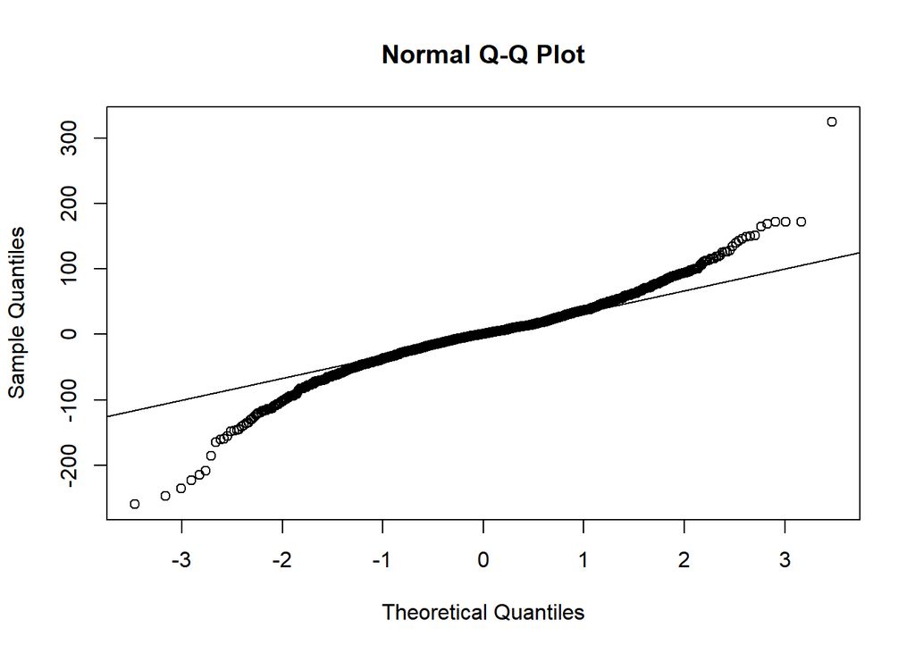

```r
qqnorm(ihsg.seasonal.residual3)
qqline(ihsg.seasonal.residual3)
```

```r
jarque.bera.test(ihsg.seasonal.residual3)
```

```
##
##  Jarque Bera Test
##
## data:  ihsg.seasonal.residual3
## X-squared = 1478.8, df = 2, p-value < 2.2e-16
```

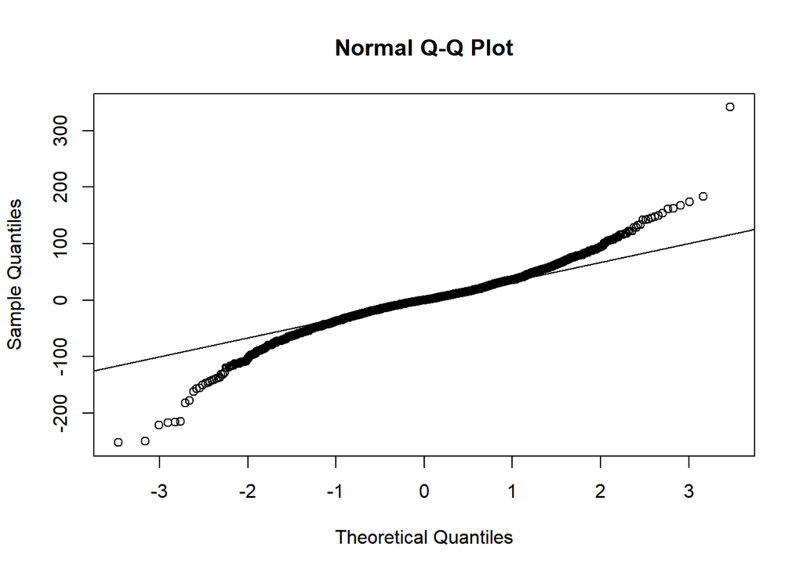

```r
qqnorm(ihsg.seasonal.residual4)
qqline(ihsg.seasonal.residual4)
```

```r
jarque.bera.test(ihsg.seasonal.residual4)
```

```
##
##  Jarque Bera Test
##
## data:  ihsg.seasonal.residual4
## X-squared = 1576.1, df = 2, p-value < 2.2e-16
```

Berdasarkan qq-plot dan uji formal Jarque Bera, sisaan cenderung tidak menyebar normal sehingga kembali kita temui bahwa asumsi normalitas tidak terpenuhi.

## Kehomogenan Ragam

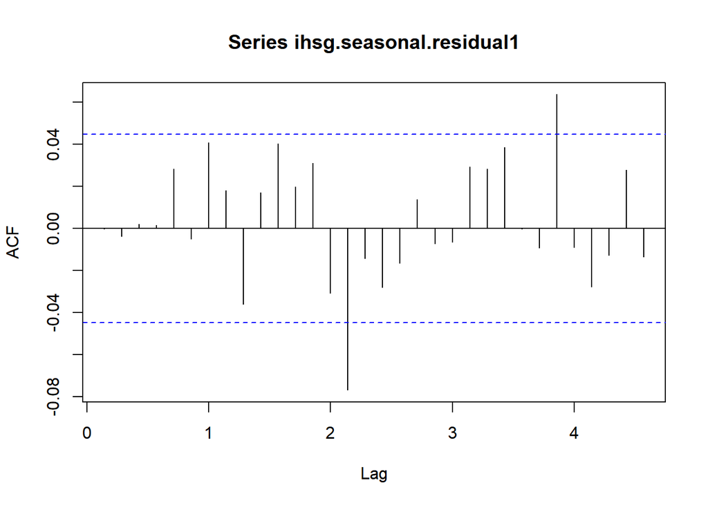

```r
acf(ihsg.seasonal.residual1)
```

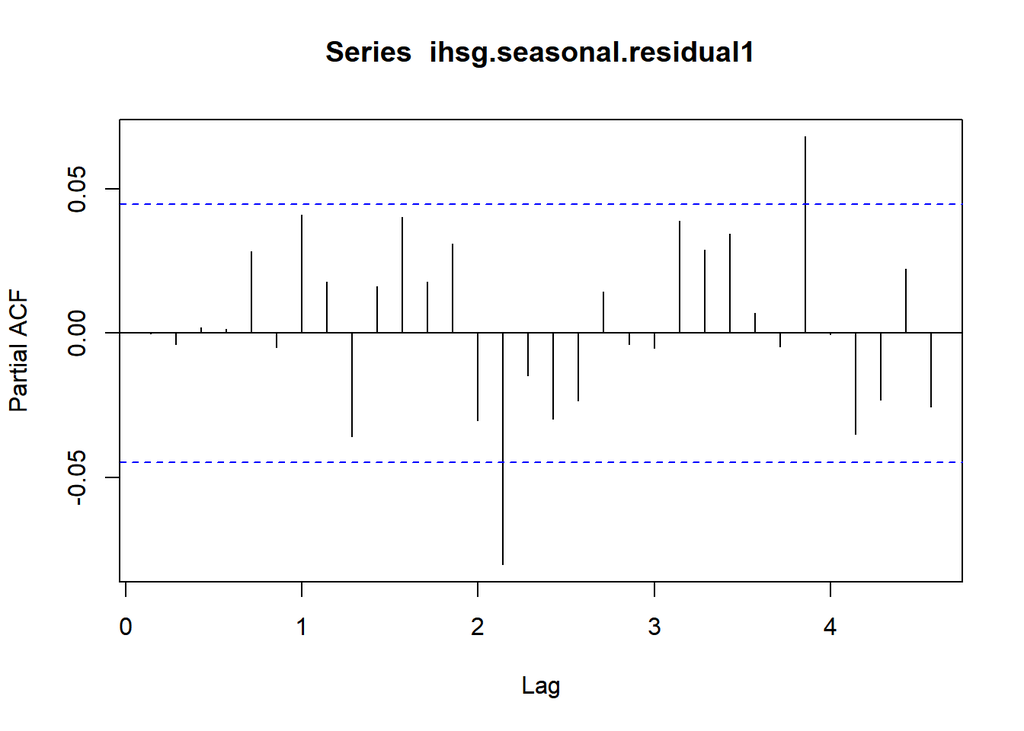

```r
pacf(ihsg.seasonal.residual1)
```

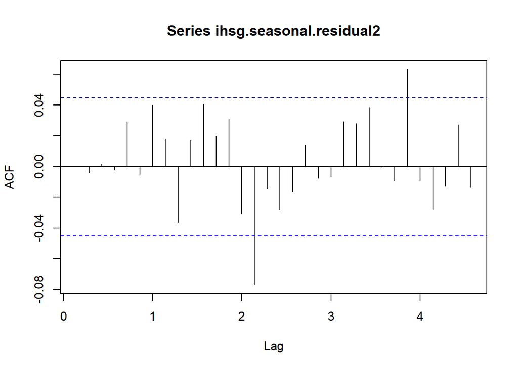

```r
acf(ihsg.seasonal.residual2)
```

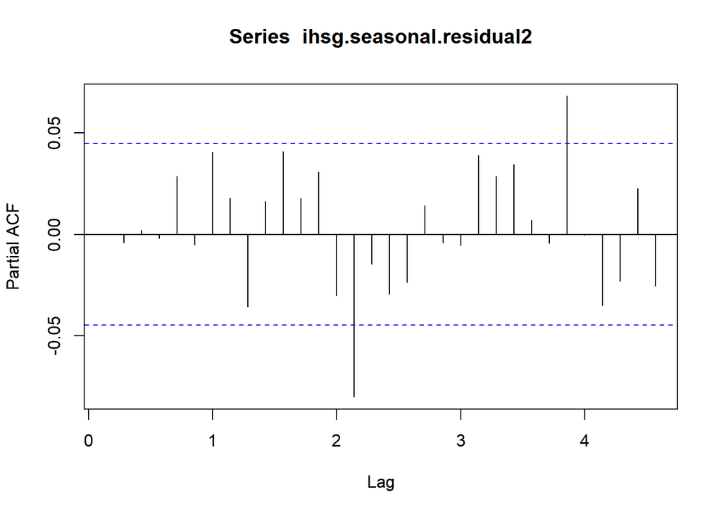

```r
pacf(ihsg.seasonal.residual2)
```

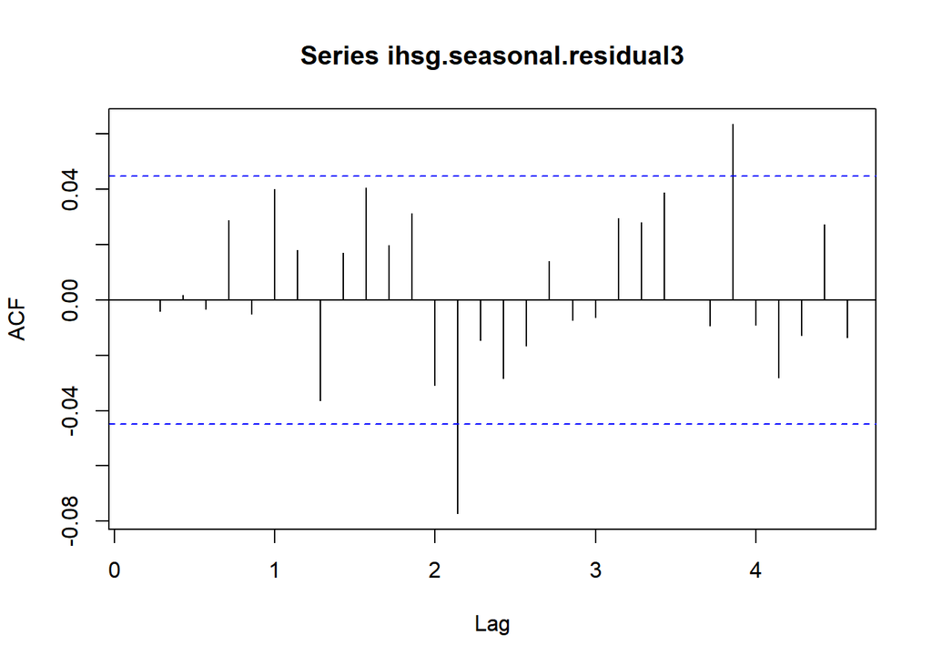

```r
acf(ihsg.seasonal.residual3)
```

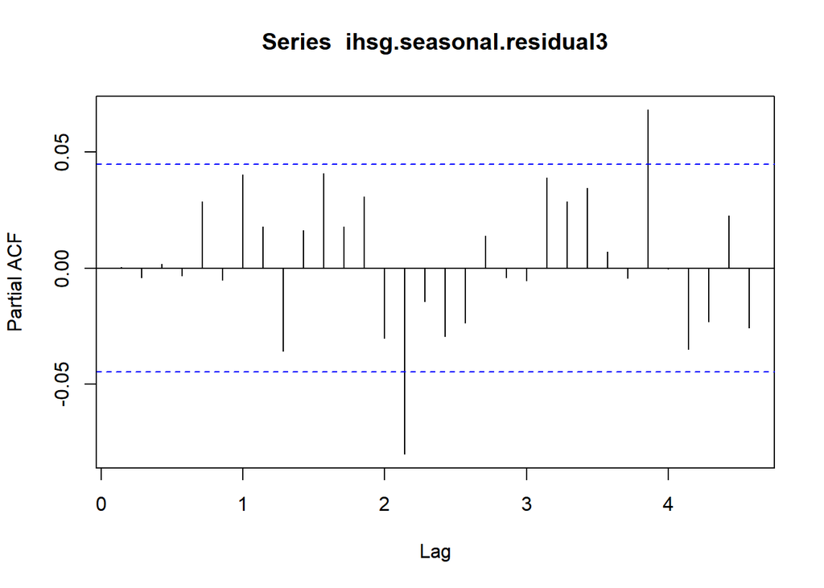

```r
pacf(ihsg.seasonal.residual3)
```

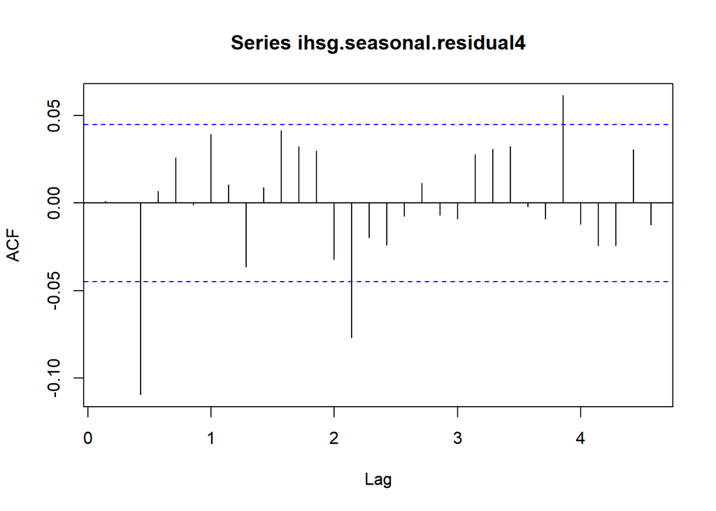

```r
acf(ihsg.seasonal.residual4)
```

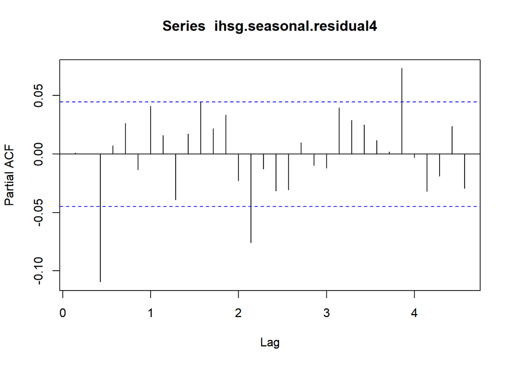

```r
pacf(ihsg.seasonal.residual4)
```

## Autokorelasi

```r
Box.test(ihsg.seasonal.residual1, type="Ljung")
```

```
##
##  Box-Ljung test
##
## data:  ihsg.seasonal.residual1
## X-squared = 0.00015221, df = 1, p-value = 0.9902
```

```r
Box.test(ihsg.seasonal.residual2, type="Ljung")
```

```
##
##  Box-Ljung test
##
## data:  ihsg.seasonal.residual2
## X-squared = 7.6967e-05, df = 1, p-value = 0.993
```

```r
Box.test(ihsg.seasonal.residual3, type="Ljung")
```

```
##
##  Box-Ljung test
##
## data:  ihsg.seasonal.residual3
## X-squared = 0.00018534, df = 1, p-value = 0.9891
```

```r
Box.test(ihsg.seasonal.residual4, type="Ljung")
```

```
##
##  Box-Ljung test
##
## data:  ihsg.seasonal.residual4
## X-squared = 0.0017072, df = 1, p-value = 0.967
```

Berdasarkan hasil Ljung-Box test, terlihat bahwa data telah memenuhi asumsi tidak adanya autokorelasi.

# Overfitting

Akan dicoba untuk melakukan overfitting dari model SARIMA dari model yang seluruh koefisiennya signifikan ARIMA(0,1,1)(0,1,1)7 dan memiliki AIC kecil dibanding model ARIMA non-seasonal yaitu:

- ARIMA(1,1,1)(0,1,1)7
- ARIMA(0,1,2)(0,1,1)7

```r
ihsg.ovt.model1 <- Arima(ihsg.seasonal, order=c(1,1,1), seasonal=c(0,1,1), method="ML")
ihsg.ovt.model2 <- Arima(ihsg.seasonal, order=c(0,1,2), seasonal=c(0,1,1), method="ML")
ihsg.ovt.model1$aic; ihsg.ovt.model2$aic;
```

```
## [1] 20081.82
```

```
## [1] 20081.67
```

```r
coeftest(ihsg.ovt.model1)
```

```
##
## z test of coefficients:
##
##        Estimate Std. Error   z value Pr(>|z|)
## ar1   0.0330625  0.1399915    0.2362   0.8133
## ma1   0.0555283  0.1385263    0.4009   0.6885
## sma1 -0.9999998  0.0099589 -100.4122   <2e-16 ***
## ---
## Signif. codes:  0 '***' 0.001 '**' 0.01 '*' 0.05 '.' 0.1 ' ' 1
```

```r
coeftest(ihsg.ovt.model2)
```

```
##
## z test of coefficients:
##
##       Estimate Std. Error  z value  Pr(>|z|)
## ma1   0.090842   0.023702   3.8327 0.0001268 ***
## ma2   0.010784   0.023879   0.4516 0.6515415
## sma1 -0.999999   0.010119 -98.8209 < 2.2e-16 ***
## ---
## Signif. codes:  0 '***' 0.001 '**' 0.01 '*' 0.05 '.' 0.1 ' ' 1
```

```r
ihsg.ovt.residual1 <- ihsg.ovt.model1$residuals
ihsg.ovt.residual2 <- ihsg.ovt.model2$residuals
```

Dari kedua model overfitting, tidak ada yang seluruh parameternya signifikan. Maka uji diagnostik dan peramalan tidak akan dilakukan

# Peramalan

- ARIMA(0,1,1) karena seluruh koefisiennya signifikan
- ARIMA(0,1,3) karena memiliki nilai AIC paling kecil diantara model ARIMA lainnya
- ARIMA(0,1,1)(0,1,1)7 karena seluruh koefisiennya signifikan
- ARIMA(0,1,3)(0,1,1)7 karena memiliki nilai AIC paling kecil diantara seluruh model yang telah dicobakan

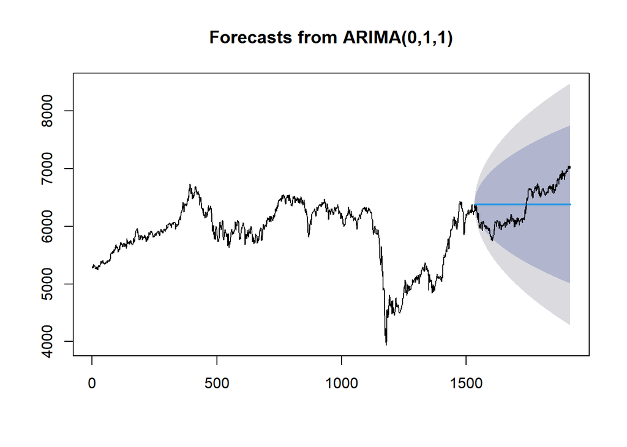

```r
ihsg.forecast1 <- forecast(Arima(ihsg.train, order=c(0,1,1), method="ML"),
                          h=test.prop)
plot(ihsg.forecast1)
lines(ihsg.test)
```

```r
accuracy(ihsg.forecast1$mean, ihsg.test)
```

```
##                 ME     RMSE     MAE       MPE     MAPE      ACF1 Theil's U
## Test set -23.01259 348.6009 321.606 -0.659804 5.069424 0.9870788  7.798878
```

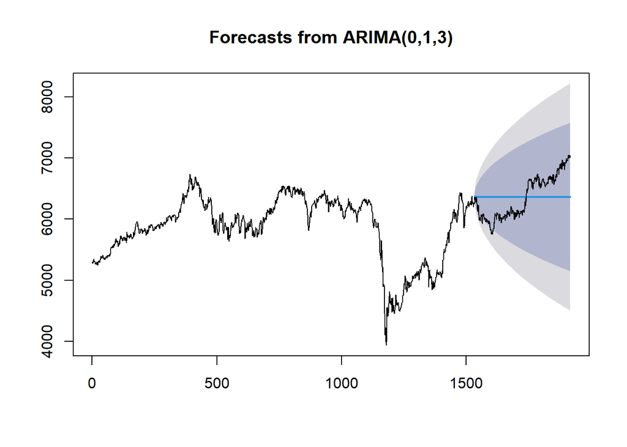

```r
ihsg.forecast2 <- forecast(Arima(ihsg.train, order=c(0,1,3), method="ML"),
                          h=test.prop)
plot(ihsg.forecast2)
lines(ihsg.test)
```

```r
accuracy(ihsg.forecast2$mean, ihsg.test)
```

```
##                 ME     RMSE      MAE        MPE     MAPE      ACF1 Theil's U
## Test set -3.736472 347.8617 320.1571 -0.3556921 5.031354 0.9870839   7.73594
```

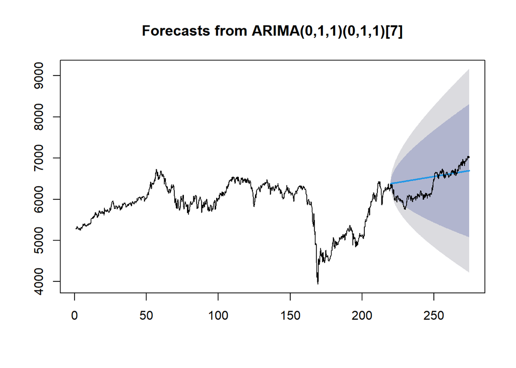

```r
ihsg.seasonal.forecast3 <- forecast(Arima(seasonal.train, order=c(0,1,1), seasonal=c(0,1,1), method="ML"),
                          h=test.prop)
plot(ihsg.seasonal.forecast3)
lines(seasonal.test)
```

```r
accuracy(ihsg.seasonal.forecast3$mean, seasonal.test)
```

```
##                 ME     RMSE      MAE       MPE     MAPE      ACF1 Theil's U
## Test set -178.4353 323.4091 267.0216 -3.042675 4.333758 0.9812338  7.564246
```

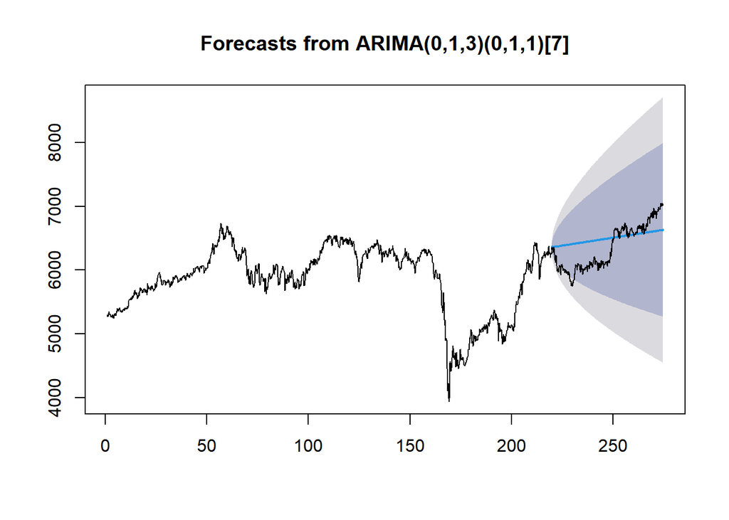

```r
ihsg.seasonal.forecast4 <- forecast(Arima(seasonal.train, order=c(0,1,3), seasonal=c(0,1,1), method="ML"),
                          h=test.prop)
plot(ihsg.seasonal.forecast4)
lines(seasonal.test)
```

```r
accuracy(ihsg.seasonal.forecast4$mean, seasonal.test)
```

```
##                 ME     RMSE      MAE       MPE    MAPE      ACF1 Theil's U
## Test set -137.5754 312.0774 265.8911 -2.407688 4.28693 0.9824294  7.245751
```

# Kesimpulan

Berdasarkan seluruh model yang telah kelompok kami coba, baik ARIMA(0,1,1), ARIMA(0,1,3), ARIMA(0,1,3), Seasonal ARIMA dengan ARIMA(0,1,1)(0,1,1)7, dan Seasonal ARIMA dengan ARIMA(0,1,3)(0,1,1)7 didapatkan seluruhnya tidak lolos uji asumsi normalitas pada uji diagnostik (termasuk model yang telah ditransformasi). Maka perlu diambil langkah yang dapat menyelesaikan masalah ketidaknormalan sisaan.

Berdasarkan nilai RMSE, MAE, dan MAPE dapat dilihat bahwa ARIMA(0,1,3)(0,1,1)7 merupakan model peramalan yang paling baik untuk dataset ini.

# Daftar Pustaka

Aldoko Listiaji Putra, Aminuddin Kasdi, Waspodo Tjipto Subroto. 2019. PENGARUH MEDIA GOOGLE EARTH TERHADAP HASIL BELAJAR BERDASARKAN KEAKTIFAN SISWA KELAS IV TEMA INDAHNYA NEGERIKU DI SEKOLAH DASAR. Jurnal Kajian Pendidikan dan Hasil Penelitian. 5(3): 5.

Anik Rufaidah, Muhamad Afif Effindi. 2018. ANALISIS TIME SERIES UNTUK MENENTUKAN MODEL TERBAIK PRODUK SONGKOK NASIONAL DI KABUPATEN GRESIK. Prosiding Seminar Nasional Matematika dan Terapannya 2018.

Anselin, L. 1988. Spatial Econometrics: Methods and Models. Kluwer Academic Publishers. The Netherlands

Arif Subekti. 2010. Pengelolaan Kas Daerah Untuk Mendukung Peningkatan Pendapatan Asli Daerah pada Pemerintah Kabupaten Pekalongan. Jurnal Kebijakan Ekonomi. 6(1):.

Draper, N. R. & Smith, H., 1998. Applied regression Analysis. Third ed. New York: John Wiley.

Ghozali, I. (2011). Aplikasi Analisis Multivariate dengan Program SPSS. Semarang: BP Universitas Diponegoro

Halim S., Bisono IN. 2008. Automatic Seasonal Autoregressive Moving Average Models and Unit Root Test Detection. International Journal of Management Science and Engineering Management. 3(4): 266-274.

Hendrawan B. 2012. Penerapan Model ARIMA Dalam Memprediksi IHSG. Jurnal Intergrasi. 4(2):205-211.

Maswar. 2017. Analisis time series model arma untuk memprediksi jumlah santri pp salafiyah syafi’iyah sukorejo 2017-2021. Jurnal Pengembangan Pemikiran dan Kebudayaan. 11(1): 59-86.

Purwanto.(2011). Statistik untuk Penelitian.Yogyakarta : Pustaka Pelajar

Rais. 2009. Pemodelan data time series dengan metode box-jenknis. Jurnal Ilmiah Matematika dan Terapan. 6(1): 1-10.

Real-Statistic. (2019). Kolomogorov – Smirnov Test For Normality. Diakses 2020.http://www.real-statistics.com/testsnormality-and-symmetry/statistical-testsnormality-symmetry/kolmogorov-smirnovtest/

Rohmawati AA, Wulandari A. 2020. Prediksi pergerakan harga saham pt. astra internasional tbk menggunakan vector auto regressive (var) stasioner dan logistic regression. Jurnal of Engineering. 7(3): 2614-2626.

Rosadi, D. 2011. Analisis Ekonometrika dan Runtun Waktu Terapan dengan R. Andi. Yogyakarta

Stephani CA. 2015. Peramalan Inflasi Nasional Berdasarkan Faktor Ekonomi Makro Menggunakan Pendekatan Time Series Klasik dan Anfis. [skripsi]. Surabaya (ID): Institut Teknologi Sepuluh Nopember.